# MoneyLion Assessment

## Objective

- To develop a ranking model that estimates and prioritizes users by their likelihood of early loan abandonment at application time, enabling more effective targeting, pricing, and operational decision-making.

## Problem

- This problem is framed as a ranking task rather than a binary classification task. At application time, the business does not need a hard yes/no prediction for each loan, but rather a prioritized list of applicants ordered by their likelihood of early abandonment. This ranking enables the business to allocate limited underwriting, marketing, and operational resources to applicants with the highest expected conversion.

```python
# Supress warnings, so that the output will be cleaner
import warnings
warnings.filterwarnings("ignore")
```

```python
# Import Libraries

# For reading data and preprocessing
import pandas as pd
import numpy as np
# interactive visualization
import matplotlib.pyplot as plt
# For Exploratory Data Analysis / Descriptive Data Analytics
import sweetviz as sv
# For explainability
import shap
```

```python
# load the data and first saperate funded and non-funded for early analysis
raw_loan_data = pd.read_csv(r"C:\Users\LENOVO\Documents\github side project\ds assessment\data\loan.csv")
funded_loan_data = raw_loan_data[raw_loan_data['isFunded']==1]
non_funded_loan_data = raw_loan_data[raw_loan_data['isFunded']==0]
```

First question, how is exactly our data?

```python
len(funded_loan_data)
```

```
38982
```

```python
len(non_funded_loan_data)
```

```
538700
```

## EDA

Why exactly there are so many non-funded loan? can we dig dive for the possible causes?

```python
# create a descriptive analysis report for non-funded loan
report = sv.analyze(non_funded_loan_data)
report.show_html('non_funded_loan_data.html')
```

When see the report, we can see the Withdraw Application takes majority of non-funded loan. can we investigate why?

```python
withdrawn_loan_data = raw_loan_data[raw_loan_data['loanStatus']=='Withdrawn Application']
len(withdrawn_loan_data)
```

```
450984
```

A quick math we can calculate that those that withdraw application takes 83.7% of non funded loan. if we can analyse why they are withdraw their loan, maybe we can convert those to funded loan, and if they pay their loan responsibly then we can generate a huge profit. how much profit are we talking?

```python
withdrawn_loan_data['loanAmount'].sum()
```

```
227083941.5
```

```python
funded_loan_data['loanAmount'].sum()
```

```
24937863.0
```

```python
withdrawn_loan_data['originallyScheduledPaymentAmount'].sum()
```

```
632966712.492999
```

```python
funded_loan_data['originallyScheduledPaymentAmount'].sum()
```

```
68349613.02305804
```

```python
roi = (funded_loan_data['originallyScheduledPaymentAmount'].sum() - funded_loan_data['loanAmount'].sum()) / funded_loan_data['loanAmount'].sum()
roi
```

```
1.7407967163448625
```

```python
roi_withdrawn = (withdrawn_loan_data['originallyScheduledPaymentAmount'].sum() - withdrawn_loan_data['loanAmount'].sum()) / withdrawn_loan_data['loanAmount'].sum()
roi_withdrawn
```

```
1.7873688835588533
```

```python
withdrawn = withdrawn_loan_data
funded = funded_loan_data

withdrawn_lead = (
    withdrawn['leadType']
    .value_counts(normalize=True)
    .rename('withdrawn_pct')
)

funded_lead = (
    funded['leadType']
    .value_counts(normalize=True)
    .rename('funded_pct')
)

lead_compare = pd.concat([withdrawn_lead, funded_lead], axis=1).fillna(0)
lead_compare
```

| leadType | withdrawn_pct | funded_pct |
| --- | --- | --- |
| bvMandatory | 0.827171 | 0.425042 |
| lead | 0.133062 | 0.296855 |
| organic | 0.032154 | 0.194910 |
| prescreen | 0.006082 | 0.033528 |
| california | 0.000951 | 0.001257 |
| rc_returning | 0.000486 | 0.047278 |
| repeat | 0.000033 | 0.000231 |
| instant-offer | 0.000027 | 0.000231 |
| lionpay | 0.000020 | 0.000257 |
| express | 0.000013 | 0.000410 |

if we comparing the lead type, we can see 82% from the withdrawn application has their lead type by mandatory. as the customer data is bought from ping tree it is possible to be much riskier. so they need to have bank verification. This might suggest a strong reason for withdraw.

```python
withdrawn['nPaidOff'].describe()

pd.cut(
    withdrawn['nPaidOff'],
    bins=[-1, 0, 1, 3, 10, 100]
).value_counts().sort_index()
```

```
nPaidOff
(-1, 0]      446290
(0, 1]         3432
(1, 3]         1016
(3, 10]         226
(10, 100]        18
Name: count, dtype: int64
```

```python
pd.concat({
    'withdrawn': withdrawn['nPaidOff'].value_counts(normalize=True) * 100,
    'funded': funded['nPaidOff'].value_counts(normalize=True) * 100
}, axis=1).fillna(0)
```

| nPaidOff | withdrawn | funded |
| --- | --- | --- |
| 0.0 | 98.959604 | 79.086779 |
| 1.0 | 0.761006 | 12.812813 |
| 2.0 | 0.171847 | 4.607171 |
| 3.0 | 0.053439 | 1.727368 |
| 4.0 | 0.023061 | 0.813634 |
| 5.0 | 0.014191 | 0.377300 |
| 6.0 | 0.009091 | 0.228434 |
| 7.0 | 0.001996 | 0.118067 |
| 11.0 | 0.001330 | 0.025667 |
| 10.0 | 0.000887 | 0.012833 |
| 14.0 | 0.000665 | 0.012833 |
| 9.0 | 0.000443 | 0.033367 |
| 8.0 | 0.000443 | 0.061600 |
| 19.0 | 0.000443 | 0.012833 |
| 12.0 | 0.000443 | 0.015400 |
| 20.0 | 0.000443 | 0.007700 |
| 18.0 | 0.000222 | 0.012833 |
| 13.0 | 0.000222 | 0.023100 |
| 17.0 | 0.000222 | 0.002567 |
| 15.0 | 0.000000 | 0.002567 |
| 21.0 | 0.000000 | 0.002567 |
| 16.0 | 0.000000 | 0.002567 |

Most of the customer profile is new to money borrowing as they are 98.95% dont have history of taking loans.

```python
withdrawn.groupby('state').size().sort_values(ascending=False)
```

```
state
OH         70684
IL         51975
MO         40212
TX         38121
WI         31719
MI         28023
TN         26416
NC         21020
IN         20919
FL         19807
SC         18880
CA         15519
NV          8479
PA          7683
VA          6686
NJ          5690
UT          5392
AL          3486
MS          3059
CO          2805
LA          2725
NM          2644
AZ          2389
KY          2292
SD          1839
MN          1538
OK          1385
GA          1379
WY          1336
CT           985
WA           976
KS           954
IA           808
DE           676
ID           558
RI           535
NE           493
HI           490
AK           217
ND           166
NY             3
OH-TEST        1
MD             1
TX-TEST        1
dtype: int64
```

Most of people who withdraw is from OHIO state. but if we are looking at big pictures, most of the application is coming from Ohio state so it no wonder a lot of application from Ohio state withdraw. We might see interesting insight if we compare it with cost of living in States. looking online, 'https://worldpopulationreview.com/state-rankings/cost-of-living-index-by-state' we can see Hawaii is the highest in cost of living but Ohio is kind of in the middle. so this means the cost of living might not be the problem as to why they withdraw their application. now maybe the reasons falls in clarity underwriting data.

```python
# import with clarity underwriting data
clarity_underwriting_data = pd.read_csv(r"C:\Users\LENOVO\Documents\github side project\ds assessment\data\clarity_underwriting_variables.csv")
# merge those data with funded and withdrawn data
withdrawn_clarity = withdrawn.merge(
    clarity_underwriting_data,
    left_on='clarityFraudId',
    right_on='underwritingid',
    how='left'
)

funded_clarity = funded.merge(
    clarity_underwriting_data,
    left_on='clarityFraudId',
    right_on='underwritingid',
    how='left'
)
```

```python
withdrawn_clarity['has_clarity'] = withdrawn_clarity['underwritingid'].notna()

withdrawn_clarity['has_clarity'].value_counts(normalize=True)
funded_clarity['has_clarity'] = funded_clarity['underwritingid'].notna()

funded_clarity['has_clarity'].value_counts(normalize=True)
```

```
has_clarity
True     0.825509
False    0.174491
Name: proportion, dtype: float64
```

```python
velocity_cols = [
    '.underwritingdataclarity.clearfraud.clearfraudinquiry.oneminuteago',
    '.underwritingdataclarity.clearfraud.clearfraudinquiry.tenminutesago',
    '.underwritingdataclarity.clearfraud.clearfraudinquiry.onehourago',
    '.underwritingdataclarity.clearfraud.clearfraudinquiry.twentyfourhoursago',
    '.underwritingdataclarity.clearfraud.clearfraudinquiry.sevendaysago',
    '.underwritingdataclarity.clearfraud.clearfraudinquiry.fifteendaysago',
    '.underwritingdataclarity.clearfraud.clearfraudinquiry.thirtydaysago',
    '.underwritingdataclarity.clearfraud.clearfraudinquiry.ninetydaysago'
]

withdrawn_clarity[velocity_cols].dtypes
```

```
.underwritingdataclarity.clearfraud.clearfraudinquiry.oneminuteago          float64
.underwritingdataclarity.clearfraud.clearfraudinquiry.tenminutesago         float64
.underwritingdataclarity.clearfraud.clearfraudinquiry.onehourago            float64
.underwritingdataclarity.clearfraud.clearfraudinquiry.twentyfourhoursago    float64
.underwritingdataclarity.clearfraud.clearfraudinquiry.sevendaysago          float64
.underwritingdataclarity.clearfraud.clearfraudinquiry.fifteendaysago        float64
.underwritingdataclarity.clearfraud.clearfraudinquiry.thirtydaysago         float64
.underwritingdataclarity.clearfraud.clearfraudinquiry.ninetydaysago         float64
dtype: object
```

```python
withdrawn_clarity['high_velocity'] = (
    withdrawn_clarity['.underwritingdataclarity.clearfraud.clearfraudinquiry.thirtydaysago'] > 3
)

withdrawn_clarity['high_velocity'].value_counts(normalize=True)
funded_clarity['high_velocity'] = (
    funded_clarity['.underwritingdataclarity.clearfraud.clearfraudinquiry.thirtydaysago'] > 3
)
withdrawn_clarity['high_velocity'].value_counts(normalize=True)
```

```
high_velocity
False    0.994042
True     0.005958
Name: proportion, dtype: float64
```

```python
fraud_indicator_cols = [
    '.underwritingdataclarity.clearfraud.clearfraudindicator.totalnumberoffraudindicators',
    '.underwritingdataclarity.clearfraud.clearfraudindicator.inputssninvalid',
    '.underwritingdataclarity.clearfraud.clearfraudindicator.inputssnrecordedasdeceased',
    '.underwritingdataclarity.clearfraud.clearfraudindicator.creditestablishedbeforeage18',
    '.underwritingdataclarity.clearfraud.clearfraudindicator.morethan3inquiriesinthelast30days',
    '.underwritingdataclarity.clearfraud.clearfraudindicator.highprobabilityssnbelongstoanother'
]
```

```python
def tf_to_binary(x):
    return 1 if str(x).upper() == 'TRUE' else 0

withdrawn_clarity[fraud_indicator_cols] = withdrawn_clarity[fraud_indicator_cols].applymap(tf_to_binary)
funded_clarity[fraud_indicator_cols] = funded_clarity[fraud_indicator_cols].applymap(tf_to_binary)
```

```python
withdrawn_clarity['fraud_flag_count'] = withdrawn_clarity[fraud_indicator_cols].sum(axis=1)
funded_clarity['fraud_flag_count'] = funded_clarity[fraud_indicator_cols].sum(axis=1)

withdrawn_clarity['fraud_flag_count'].value_counts(normalize=True)
```

```
fraud_flag_count
0    0.999525
1    0.000461
2    0.000013
Name: proportion, dtype: float64
```

from here, we can save to say that most of the customer dont have any fraud flag. as the majority of customer has 0 flag count.

```python
identity_cols = [
    '.underwritingdataclarity.clearfraud.clearfraudidentityverification.overallmatchresult',
    '.underwritingdataclarity.clearfraud.clearfraudidentityverification.ssnnamematch',
    '.underwritingdataclarity.clearfraud.clearfraudidentityverification.ssndobmatch'
]

withdrawn_clarity[identity_cols].value_counts(dropna=False)
funded_clarity[identity_cols].value_counts(dropna=False)
```

```
.underwritingdataclarity.clearfraud.clearfraudidentityverification.overallmatchresult  .underwritingdataclarity.clearfraud.clearfraudidentityverification.ssnnamematch  .underwritingdataclarity.clearfraud.clearfraudidentityverification.ssndobmatch
partial                                                                                match                                                                            match                                                                             13946
match                                                                                  match                                                                            match                                                                              9355
NaN                                                                                    NaN                                                                              NaN                                                                                6828
partial                                                                                match                                                                            partial                                                                            3962
                                                                                       partial                                                                          match                                                                              1759
                                                                                       match                                                                            invalid                                                                            1327
                                                                                       mismatch                                                                         match                                                                               679
                                                                                       partial                                                                          partial                                                                             321
                                                                                       mismatch                                                                         partial                                                                             184
other                                                                                  unavailable                                                                      invalid                                                                             128
partial                                                                                match                                                                            mismatch                                                                            117
                                                                                       mismatch                                                                         mismatch                                                                             86
                                                                                       unavailable                                                                      invalid                                                                              79
mismatch                                                                               mismatch                                                                         mismatch                                                                             63
partial                                                                                match                                                                            unavailable                                                                          44
```

[output cut: 9 more lines]

```python
weak_identity_values = [
    'partial',
    'mismatch',
    'invalid',
    'unavailable'
]

withdrawn_clarity['weak_identity_match'] = (
    withdrawn_clarity[
        '.underwritingdataclarity.clearfraud.clearfraudidentityverification.overallmatchresult'
    ]
    .str.lower()
    .isin(weak_identity_values)
)
withdrawn_clarity['weak_identity_match'].value_counts(normalize=True)
funded_clarity['weak_identity_match'] = (
    funded_clarity[
        '.underwritingdataclarity.clearfraud.clearfraudidentityverification.overallmatchresult'
    ]
    .str.lower()
    .isin(weak_identity_values)
)
withdrawn_clarity['weak_identity_match'].value_counts(normalize=True)
```

```
weak_identity_match
False    0.994477
True     0.005523
Name: proportion, dtype: float64
```

The majority of customers also dont have weak identity match, which means their identity verification is clear and not suspicious.

```python
credit_depth_cols = [
    '.underwritingdataclarity.clearfraud.clearfraudindicator.creditestablishedbeforeage18',
    '.underwritingdataclarity.clearfraud.clearfraudindicator.creditestablishedpriortossnissuedate',
    '.underwritingdataclarity.clearfraud.clearfraudindicator.currentaddressreportedbynewtradeonly'
]

withdrawn_clarity['thin_file_flag'] = (
    withdrawn_clarity[credit_depth_cols].sum(axis=1) > 0
)
withdrawn_clarity['thin_file_flag'].value_counts(normalize=True)
funded_clarity['thin_file_flag'] = (
    funded_clarity[credit_depth_cols].sum(axis=1) > 0
)
withdrawn_clarity['thin_file_flag'].value_counts(normalize=True)
```

```
thin_file_flag
False    0.999379
True     0.000621
Name: proportion, dtype: float64
```

The thin file flag is contains information of overall credit behavior of the customer. thin file suggest the customer has limited credit history 'https://www.supermoney.com/encyclopedia/thin-file'. so most of the customers that withdraw dont have thin file flag, which is good. now that we have analyse possible reasons why they withdraw. lets compile and see why they withraw.

```python
# For analysis only, not for modelling
def assign_withdraw_reason(row):
    if not row['has_clarity']:
        return 'Early abandonment'
    if row['fraud_flag_count'] >= 2:
        return 'Fraud indicators'
    if row['weak_identity_match']:
        return 'Identity mismatch'
    if row['high_velocity']:
        return 'High inquiry velocity'
    if row['thin_file_flag']:
        return 'Thin credit file'
    return 'Unknown'

withdrawn_clarity['withdraw_reason'] = withdrawn_clarity.apply(assign_withdraw_reason, axis=1)
withdrawn_clarity['withdraw_reason'].value_counts()
```

```
withdraw_reason
Early abandonment        447233
Identity mismatch          2487
High inquiry velocity       945
Unknown                     303
Thin credit file             10
Fraud indicators              6
Name: count, dtype: int64
```

Now, from our analysis we can figure out that **most** of the customers have early withdraw from their loan application. as to exact why they withdraw, we might need to see a bigger picture, which means a lot more data, such as feedback data for example which compiles the customer feedback as to why they withdraw their loan application early. then maybe we can use some sentiment analysis to figure out why they behave like that and maybe improve our customer experience service or what ever insight we found later.

```python
early_abandonment = withdrawn_clarity[withdrawn_clarity['withdraw_reason']=='Early abandonment']
```

now let see for those that is withdrawn early how they are different with those customer that managed to be funded. might be their apr is different?

```python
funded_clarity['apr'].describe()
```

```
count    38982.000000
mean       527.410074
std        124.604931
min          0.000000
25%        449.990000
50%        590.000000
75%        601.000000
max        705.590000
Name: apr, dtype: float64
```

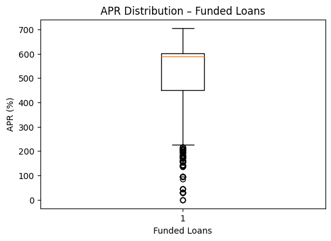

```python
plt.figure(figsize=(6, 4))
plt.boxplot(
    funded_clarity['apr'].dropna(),
    vert=True,
    showfliers=True
)
plt.title('APR Distribution – Funded Loans')
plt.ylabel('APR (%)')
plt.xlabel('Funded Loans')
plt.show()
```

```python
early_abandonment['apr'].describe()
```

```
count    443662.000000
mean        555.179369
std         108.760890
min           0.000000
25%         490.000000
50%         590.000000
75%         625.000000
max         681.000000
Name: apr, dtype: float64
```

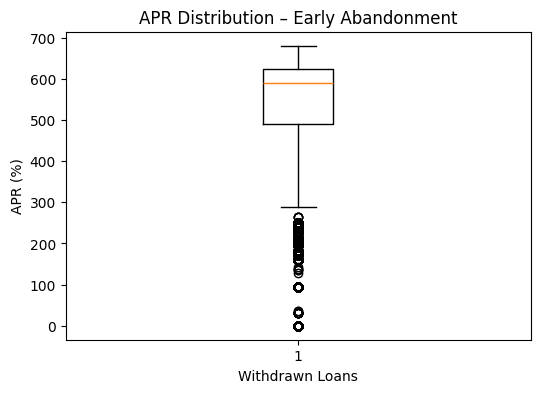

```python
plt.figure(figsize=(6, 4))
plt.boxplot(
    early_abandonment['apr'].dropna(),
    vert=True,
    showfliers=True
)
plt.title('APR Distribution – Early Abandonment')
plt.ylabel('APR (%)')
plt.xlabel('Withdrawn Loans')
plt.show()
```

from the APR distribution we can see that not much different from funded and early withdraw applicant. the 75% percentile and 25% percentile of those that withdraw early is a bit higher than those that is funded. might be the loan amount has different pattern?

```python
funded_clarity['loanAmount'].describe()
```

```
count    38982.000000
mean       639.727644
std        478.619761
min        100.000000
25%        375.000000
50%        500.000000
75%        700.000000
max       4687.000000
Name: loanAmount, dtype: float64
```

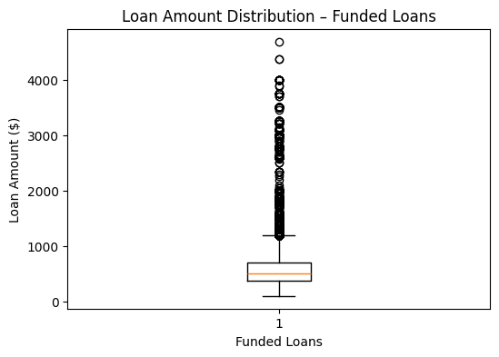

```python
plt.figure(figsize=(6, 4))
plt.boxplot(
    funded_clarity['loanAmount'].dropna(),
    vert=True,
    showfliers=True
)
plt.title('Loan Amount Distribution – Funded Loans')
plt.ylabel('Loan Amount ($)')
plt.xlabel('Funded Loans')
plt.show()
```

```python
early_abandonment['loanAmount'].describe()
```

```
count    445311.000000
mean        503.858380
std         297.633579
min           0.000000
25%         350.000000
50%         500.000000
75%         500.000000
max        5000.000000
Name: loanAmount, dtype: float64
```

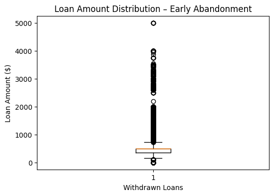

```python
plt.figure(figsize=(6, 4))
plt.boxplot(
    early_abandonment['loanAmount'].dropna(),
    vert=True,
    showfliers=True
)
plt.title('Loan Amount Distribution – Early Abandonment')
plt.ylabel('Loan Amount ($)')
plt.xlabel('Withdrawn Loans')
plt.show()
```

now for loan amount we can see the difference, where they concentrated with loan amount of $500. this might be the default loan offer that bank gives. as we can see from funded loans have real tail on 75% percentile with $700. how about Originally Scheduled Payment Amount?

```python
funded_clarity['originallyScheduledPaymentAmount'].describe()
```

```
count    38982.000000
mean      1753.363425
std       1282.300386
min        187.620000
25%       1035.560000
50%       1379.000000
75%       1995.877500
max      16868.150000
Name: originallyScheduledPaymentAmount, dtype: float64
```

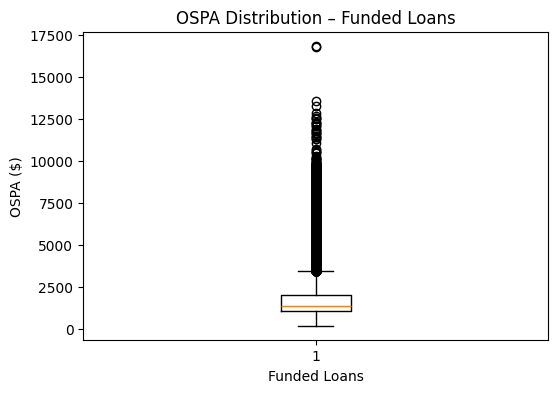

```python
plt.figure(figsize=(6, 4))
plt.boxplot(
    funded_clarity['originallyScheduledPaymentAmount'].dropna(),
    vert=True,
    showfliers=True
)
plt.title('OSPA Distribution – Funded Loans')
plt.ylabel('OSPA ($)')
plt.xlabel('Funded Loans')
plt.show()
```

```python
early_abandonment['originallyScheduledPaymentAmount'].describe()
```

```
count    447233.000000
mean       1399.534973
std         872.641029
min        -816.710000
25%        1025.490000
50%        1245.190000
75%        1599.420000
max       19005.960000
Name: originallyScheduledPaymentAmount, dtype: float64
```

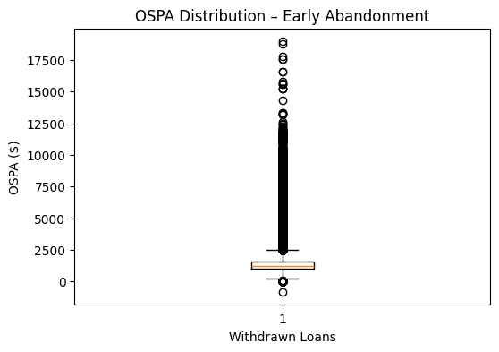

```python
plt.figure(figsize=(6, 4))
plt.boxplot(
    early_abandonment['originallyScheduledPaymentAmount'].dropna(),
    vert=True,
    showfliers=True
)
plt.title('OSPA Distribution – Early Abandonment')
plt.ylabel('OSPA ($)')
plt.xlabel('Withdrawn Loans')
plt.show()
```

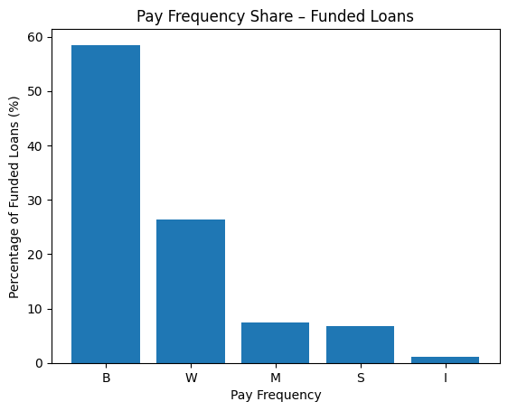

```python
pf_pct = funded_clarity['payFrequency'].value_counts(normalize=True) * 100

plt.figure()
plt.bar(pf_pct.index, pf_pct.values)
plt.xlabel('Pay Frequency')
plt.ylabel('Percentage of Funded Loans (%)')
plt.title('Pay Frequency Share – Funded Loans')
plt.show()
```

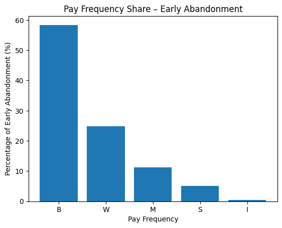

```python
pf_pct = early_abandonment['payFrequency'].value_counts(normalize=True) * 100

plt.figure()
plt.bar(pf_pct.index, pf_pct.values)
plt.xlabel('Pay Frequency')
plt.ylabel('Percentage of Early Abandonment (%)')
plt.title('Pay Frequency Share – Early Abandonment')
plt.show()
```

if we look at the pay frequency, it is not likely the reason why customers abandon their loan application. as they are mostly in the same distribution other than in funded, they more offered to pay in semi-monthly compare to EA.

## Model Development

in real world scenario, it is very hard to figure out or classify if the applicant will early abandon or will continue the loan process until funded. what i plan to build is a ranker where it ranks the probability of those that least likely to abandon their application and focus on them rather than classify those who will get funded or those who witdraw from their application. then we will focus on them like maybe we can improve their User Experience or whatever that help them hooked to take loans with the bank.

First, lets see how our data distribution

```python
len(funded_clarity)
```

```
38982
```

```python
len(withdrawn_clarity)
```

```
450984
```

from simple calculation we can see that funded loans is just around 8% of total loans combined. so we got extreme imbalance dataset here, we better use it as a ranker rather than classifier as they will really heavy on majority class prediction. for model that is related to loan use case, i figured we need to emphasis on model interpretability and explainability as in banking industry, the model should be easy to evaluate and verify. they need to comply with relevant law and rules standards. 'https://www.techtarget.com/searchenterpriseai/feature/Interpretability-vs-explainability-in-AI-and-machine-learning' thats why in this scenario i will just introduce logistic regression for this use case. as it is traditional ML and it lesser complex than other algorithm such as Neaural Network etc.

```python
# concat the data
df = pd.concat([funded_clarity, withdrawn_clarity], axis=0)
#  create is returning customer as it is much easier to interpret
df['is_returning_customer'] = (df['nPaidOff'] > 0).astype(int)
# create early abandonment feature for target variable
df['early_abandonment'] = (
    (df['loanStatus'] == 'Withdrawn Application') &
    (df['has_clarity'] == False)
).astype(int)
df['early_abandonment'].value_counts(normalize=True)
```

```
early_abandonment
1    0.912784
0    0.087216
Name: proportion, dtype: float64
```

after we concat the data, we need to remove not needed columns such as those that will be target leakage for example withdraw reason, fpStatus, approved etc. we also need to remove identifier because it didnt provide predictive values such as ssn, loanid etc. then there also proxy leakage where it is not the target but it leak decision logics such as hasclarity, hasCF etc. and then remove the columns where was this column will be known before we make the prediction.

```python
#  drop not needed columns
DROP_COLS = [
    'loanId',
    'anon_ssn',
    'clarityFraudId',
    'underwritingid',
    'withdraw_reason',
    'loanStatus',
    'originated',
    'originatedDate',
    'approved',
    'isFunded',
    'nPaidOff',
    'hasCF',
    'has_clarity',
    'fpStatus',
]
df = df.drop(columns=DROP_COLS, errors='ignore')
```

```python
BINARY_FEATURES = [
    'is_returning_customer',
]

CAT_FEATURES = [
    'payFrequency',
    'state',
    'leadType'
]

NUM_FEATURES = [
    'loanAmount',
    'apr',
    'leadCost'
]
```

now why we dont use resampling technique such as SMOTE to balance the dataset? this is because resample or data augmentation will create a synthetic data samples which we dont want if we want our model to be easily validate and interpretable for regulated industry such as banks. but we can use class_weight='balanced' to penalize more on minority class mistakes. 'https://stats.stackexchange.com/questions/638852/is-it-really-so-bad-to-do-smote-on-the-training-set-before-crossvalidation'

```python
from sklearn.model_selection import train_test_split
from sklearn.linear_model import LogisticRegression
from sklearn.compose import ColumnTransformer
from sklearn.preprocessing import OrdinalEncoder, OneHotEncoder
from sklearn.impute import SimpleImputer
from imblearn.pipeline import Pipeline

ALL_CAT_FEATURES = BINARY_FEATURES + CAT_FEATURES

X = df[NUM_FEATURES + ALL_CAT_FEATURES]
y = df['early_abandonment']
X_train, X_val, y_train, y_val = train_test_split(
    X,
    y,
    test_size=0.2,
    stratify=y,
    random_state=42
)
```

```python
# here we focus on creating the preprocessing pipeline
# for numeric transformer, i use median imputation
numeric_transformer = Pipeline(steps=[
    ('imputer', SimpleImputer(strategy='median'))
])

# for categorical transformer, i use most frequent imputation and ordinal encoding because the categorical variable are one hot in nature
categorical_transformer = Pipeline(steps=[
    ('imputer', SimpleImputer(strategy='most_frequent')),
    ('encoder', OneHotEncoder(
        handle_unknown='ignore'
    ))
])

preprocessor = ColumnTransformer(
    transformers=[
        ('num', numeric_transformer, NUM_FEATURES),
        ('cat', categorical_transformer, ALL_CAT_FEATURES)
    ]
)
```

```python
# here we create the final and combined pipeline then train the logistic regression model
clf = Pipeline(steps=[
    ('preprocessor', preprocessor),

    ('model', LogisticRegression(
        max_iter=2000,
        class_weight='balanced',
        solver='lbfgs',
    ))
])
clf.fit(X_train, y_train)
```

```
Pipeline(steps=[('preprocessor',
                 ColumnTransformer(transformers=[('num',
                                                  Pipeline(steps=[('imputer',
                                                                   SimpleImputer(strategy='median'))]),
                                                  ['loanAmount', 'apr',
                                                   'leadCost']),
                                                 ('cat',
                                                  Pipeline(steps=[('imputer',
                                                                   SimpleImputer(strategy='most_frequent')),
                                                                  ('encoder',
                                                                   OneHotEncoder(handle_unknown='ignore'))]),
                                                  ['is_returning_customer',
                                                   'payFrequency', 'state',
                                                   'leadType'])])),
                ('model',
                 LogisticRegression(class_weight='balanced', max_iter=2000))])
```

## Model Validation

```python
from sklearn.metrics import roc_auc_score, classification_report, average_precision_score
y_prob = clf.predict_proba(X_val)[:, 1]
print("ROC AUC:", roc_auc_score(y_val, y_prob))
print("PR AUC:", average_precision_score(y_val, y_prob))
```

```
ROC AUC: 0.7735295842834387
PR AUC: 0.9649814593572854
```

```python
# we create classification report for different thresholds
for t in [0.1, 0.2, 0.3, 0.4, 0.5]:
    y_pred = (y_prob >= t).astype(int)
    print(f"\nThreshold: {t}")
    print(classification_report(y_val, y_pred))
```

```
Threshold: 0.1
              precision    recall  f1-score   support

           0       0.79      0.23      0.36      8547
           1       0.93      0.99      0.96     89447

    accuracy                           0.93     97994
   macro avg       0.86      0.61      0.66     97994
weighted avg       0.92      0.93      0.91     97994


Threshold: 0.2
              precision    recall  f1-score   support

           0       0.59      0.28      0.38      8547
           1       0.93      0.98      0.96     89447

    accuracy                           0.92     97994
   macro avg       0.76      0.63      0.67     97994
weighted avg       0.91      0.92      0.91     97994


Threshold: 0.3
              precision    recall  f1-score   support

           0       0.39      0.41      0.40      8547
           1       0.94      0.94      0.94     89447

    accuracy                           0.89     97994
   macro avg       0.67      0.67      0.67     97994
weighted avg       0.90      0.89      0.89     97994


Threshold: 0.4
              precision    recall  f1-score   support

           0       0.27      0.54      0.37      8547
           1       0.95      0.86      0.91     89447

    accuracy                           0.84     97994
   macro avg       0.61      0.70      0.64     97994
weighted avg       0.89      0.84      0.86     97994


Threshold: 0.5
              precision    recall  f1-score   support

           0       0.24      0.61      0.35      8547
           1       0.96      0.82      0.88     89447

    accuracy                           0.80     97994
   macro avg       0.60      0.71      0.61     97994
weighted avg       0.89      0.80      0.84     97994
```

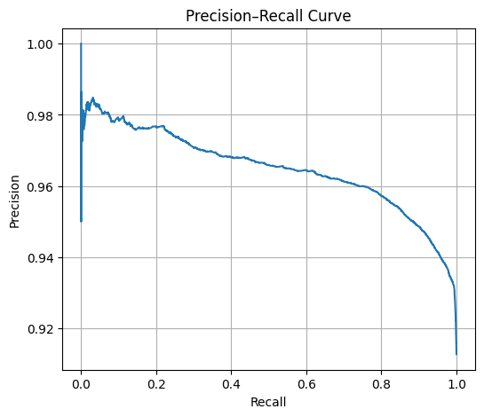

```python
from sklearn.metrics import precision_recall_curve
precision, recall, thresholds = precision_recall_curve(y_val, y_prob)

plt.figure(figsize=(6, 5))
plt.plot(recall, precision)
plt.xlabel('Recall')
plt.ylabel('Precision')
plt.title('Precision–Recall Curve')
plt.grid()
plt.show()
```

why do we do threshold analysis? this is to check probability calibration. as we can see changing the threshold didnt give unstable performance across treshold. from the evaluation metric, we can see the high presicion on class 1 (withdraw early) and poor recall on class 0 (dont withdraw). what metric should we focus as ranker is ROC-AUC (Receiver Operating Characateristic-Area Uder Curve) and PR-AUC (Precision Recall-Area Under Curve). this will measure how well positives are ranked above negatives and they are independent of treshold. with ROC-AUC is 0.77 show good ranking power, as it meaningfully orders risk even if not perfect. the PR-AUC is 0.96 shows excellent in finding early withdrawer.

## Business use case

now that we able to conclude that the model is working well for ranking, now is the business use case we all want to know. how good is the model to predicting customer who wont withdraw early.

```python
# this is the baseline percentage of non-early abandon/funded loan
# in overall validation set, the non abandonment rate is 8.72%
print((y_val == 0).mean()*100)
```

```
8.721962569136887
```

```python
#  non abandonment rate in k
def recall_at_k(y_true, y_score, k):
    idx = np.argsort(y_score)[:k]
    return (y_true.iloc[idx] == 0).mean()

for k in [1000, 5000, 10000]:
    print(f"Recall at {k}: {recall_at_k(y_val, y_prob, k=k)}")
```

```
Recall at 1000: 0.861
Recall at 5000: 0.5416
Recall at 10000: 0.3691
```

```python
df_val = X_val.copy()
df_val['p_abandon'] = y_prob
df_val['y'] = y_val
# sort the value from least likely to abandon to most likely
df_val = df_val.sort_values('p_abandon')
```

```python
for pct in [0.05, 0.1, 0.2]:
    top = df_val.head(int(pct * len(df_val)))
    rate = (top['y'] == 0).mean()
    print(f"Top {int(pct*100)}% non-abandonment rate: {rate:.2%}")
```

```
Top 5% non-abandonment rate: 54.77%
Top 10% non-abandonment rate: 37.32%
Top 20% non-abandonment rate: 25.44%
```

```python
# snip of top 10
top_10.head(10)
```

|  | loanAmount | apr | leadCost | is_returning_customer | payFrequency | state | leadType | p_abandon | y |
| --- | --- | --- | --- | --- | --- | --- | --- | --- | --- |
| 29222 | 500.0 | 390.0 | 0 | 1 | S | MN | rc_returning | 0.004693 | 0 |
| 5415 | 1000.0 | 480.0 | 0 | 1 | B | AZ | rc_returning | 0.005212 | 0 |
| 8640 | 300.0 | 265.0 | 0 | 1 | B | NJ | rc_returning | 0.005287 | 0 |
| 10578 | 500.0 | 590.0 | 0 | 1 | W | AZ | rc_returning | 0.005503 | 0 |
| 33418 | 1500.0 | 265.0 | 0 | 1 | B | PA | rc_returning | 0.005525 | 0 |
| 924 | 700.0 | 465.0 | 0 | 1 | S | CT | rc_returning | 0.005528 | 0 |
| 1342 | 1200.0 | 390.0 | 0 | 1 | S | NJ | rc_returning | 0.005630 | 0 |
| 32479 | 400.0 | 565.0 | 0 | 1 | W | MN | rc_returning | 0.005688 | 0 |
| 20144 | 700.0 | 590.0 | 0 | 1 | W | MN | rc_returning | 0.005736 | 0 |
| 27433 | 800.0 | 475.0 | 200 | 1 | I | OH | lead | 0.005820 | 0 |

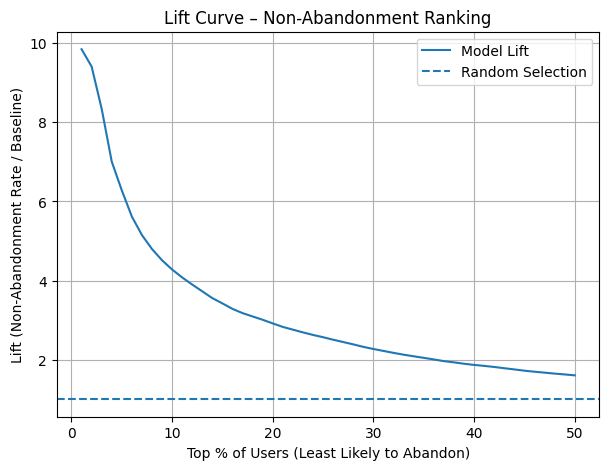

```python
df_lift = pd.DataFrame({
    'y_true': y_val,
    'score': y_prob
})
df_lift = df_lift.sort_values('score').reset_index(drop=True)
baseline_rate = (df_lift['y_true'] == 0).mean()
percentiles = np.linspace(0.01, 0.5, 50)  # 1% to 50%
lifts = []

for p in percentiles:
    k = int(p * len(df_lift))
    top_k = df_lift.iloc[:k]
    rate = (top_k['y_true'] == 0).mean()
    lift = rate / baseline_rate
    lifts.append(lift)
plt.figure(figsize=(7, 5))
plt.plot(percentiles * 100, lifts, label='Model Lift')
plt.axhline(1, linestyle='--', label='Random Selection')

plt.xlabel('Top % of Users (Least Likely to Abandon)')
plt.ylabel('Lift (Non-Abandonment Rate / Baseline)')
plt.title('Lift Curve – Non-Abandonment Ranking')
plt.legend()
plt.grid()
plt.show()
```

The lift curve shows how much more likely a user is to fund compared to random selection as we move down the ranking. In the top 5% least-likely-to-abandon users, the model achieves over 6× lift, meaning these users are more than six times as likely to fund as an average applicant.

the baseline meaning, if we pick at random 100, only ~9 out of 100 that will not abandon. now if we focus on customers that the model thinks are least likely to abandon, how much better do we do than random? Compared to a baseline non-abandonment rate of 8.7%, the model increases non-abandonment to 37% in the top 10% least-likely users and over 54% in the top 5%, representing a **4–6×** lift over random selection. This then demonstrated that the model is highly effective for priotization and resource allocation, even with highly imbalanced funnel.

### Explainability

now that we able to ranking application from least likely to abandon, we need to know why the model behaviour is like that. And SHAP can help us with that. SHAP values were used to interpret model outputs at both the global and individual level, allowing us to identify the primary drivers of abandonment risk and validate that model behavior aligns with domain intuition.

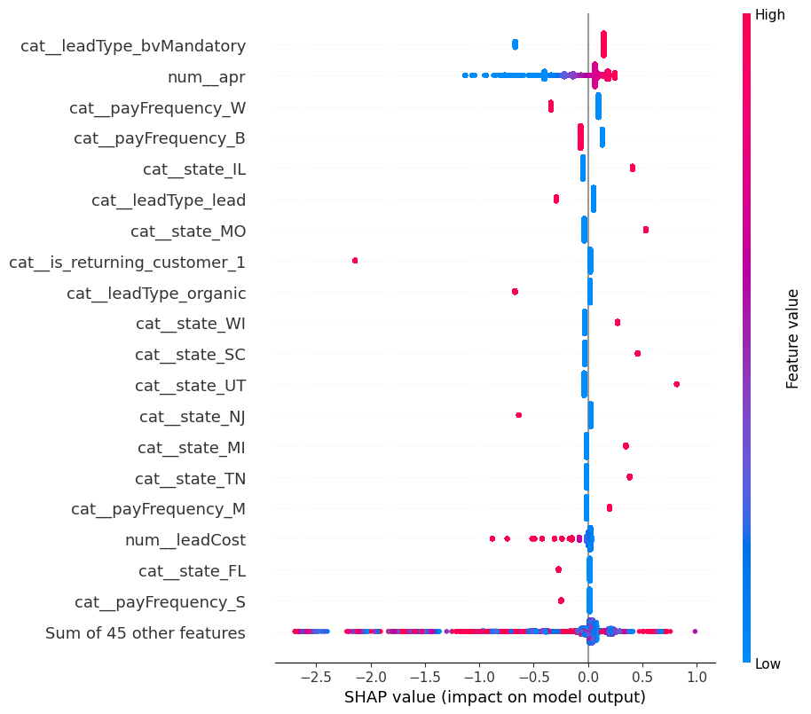

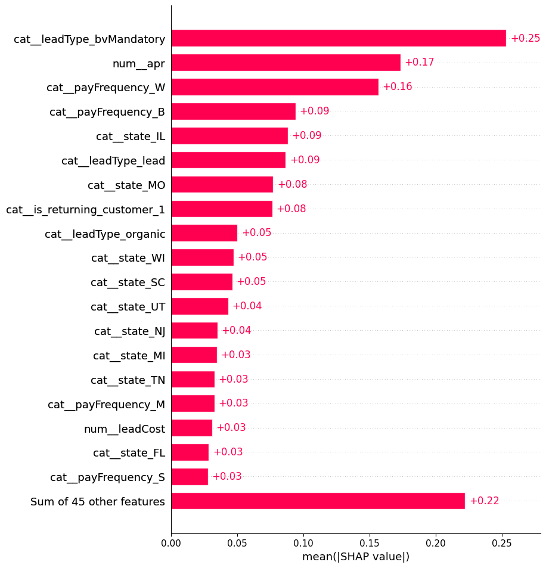

```python
preprocessor = clf.named_steps['preprocessor']
model = clf.named_steps['model']
X_val_transformed = preprocessor.transform(X_val)
feature_names = preprocessor.get_feature_names_out()
explainer = shap.LinearExplainer(
    model,
    X_val_transformed,
    feature_names=feature_names
)
shap_values = explainer(X_val_transformed)
shap.plots.beeswarm(shap_values, max_display=20)
shap.plots.bar(shap_values, max_display=20)
```

## Next work

As a next step, I would like to evaluate whether a more flexible model such as XGBoost can further improve ranking quality, particularly in identifying high-value users. This comparison would focus on incremental lift at the top of the ranking and potential business impact rather than raw classification accuracy.